# Global Seafood, 96860

Hu Can, Lew Choon Hean, Ma Xianzhou, Xu Yifei

2024-04-19

# From Cash to Catch: How does a country’s fishing industry relate to its income level?

### Loading All Required Libraries

```r
library(tidyverse)
library(maps)
library(RColorBrewer)
```

### Loading All Datasets

```r
tuesdata <- tidytuesdayR::tt_load('2021-10-12')
```

```
## --- Compiling #TidyTuesday Information for 2021-10-12 ----
```

```
## --- There are 7 files available ---
```

```
## --- Starting Download ---
```

```
## --- Download complete ---
```

```r
farmed <- tuesdata$`aquaculture-farmed-fish-production`
captured_vs_farmed <- tuesdata$`capture-fisheries-vs-aquaculture`
captured <- tuesdata$`capture-fishery-production`
consumption <- tuesdata$`fish-and-seafood-consumption-per-capita`
stock <- tuesdata$`fish-stocks-within-sustainable-levels`
fishery <- tuesdata$`global-fishery-catch-by-sector`
production <- tuesdata$`seafood-and-fish-production-thousand-tonnes`
```

# 1. Introduction

Our group chose to work on the world fishery data. It comprises 7 datasets: `farmed`, `captured_vs_farmed`, `captured`, `consumption`, `stock`, `fishery` and `production`, of which the first 3 columns are `Entity` which specifies the name of the country, `Code` which indicates the country code and `Year` which states the year of the data. The other columns mainly contain numerical data regarding fishery, such as `Aquaculture production` and `Capture fisheries production`. 6 datasets provide distinct information except `captured_vs_farmed` which simply combines `captured` and `farmed`. Upon primary investigation, we discovered that `captured_vs_farmed`, `consumption` and `production` provide more comprehensive information, detailing annual production or consumption data per country or region, as compared to `stock` and `fishery`that present aggregated data for the world. Therefore, we decided to focus our analysis on these 3 datasets.

Further observing specific values of the columns within the 3 datasets, we uncovered that the `Entity` column encompasses not only individual countries but also geographical regions or groups of countries. These regions do not have specific country codes, and can be identified by checking if `Code` is a null value, as demonstrated below.

```r
captured_vs_farmed %>% filter(is.na(Code)) %>% distinct(Entity)
```

```
## # A tibble: 47 × 1
##    Entity
##    <chr>
##  1 Africa Eastern and Southern
##  2 Africa Western and Central
##  3 Arab World
##  4 Caribbean Small States
##  5 Central Europe and the Baltics
##  6 Early-demographic dividend
##  7 East Asia & Pacific
##  8 East Asia & Pacific (IDA & IBRD)
##  9 East Asia & Pacific (excluding high income)
## 10 Euro area
## # ℹ 37 more rows
```

This inspired us to focus on groups rather than individual countries, which we believe would enable us to discern trends systematically and comprehensively on a broader level, yielding valuable insights.

The question we aim to address is how a country’s fishing industry relates to its income level, as we hypothesise that specific trends exist within the fishing industry that varies according to the income level of the countries, as many interconnected factors pertinent to national income can significantly influence the development and dynamics of specific industries within a nation. We opted to categorise the countries into low-income, middle-income and high-income groups, which is included in the `captured_vs_farmed` dataset.

### Data cleaning and visualisation

To standardise the income group classification to ensure consistency and comparability across all datasets, we created a new variable `income_group` and assigned each country in the datasets `production` and `consumption` to their respective income groups based on the World Bank’s classification in 2023, which will be included in the data cleaning process for Visualisations 2 and 3.

```r
income_group <- c("Low income", "Middle income", "High income")  # global variable
```

# 2. Visualisations

## 2.1 Visualisation 1

### Captured and Farmed Fish Production Across Income Groups over Time

For data cleaning, we filtered the dataset to include only rows where the country or region specified in the `Entity` column is found in `income_group`. Next, we created a new column `Total` by adding `Aquature` to `Capture`. We then converted the `Entity` column to a factor with levels specified by `income_group`. Lastly, we restructured the dataset from wide to long format, where columns Aquature, Capture, and Total are melted into two columns: `Type` (the type of methods used for fishery production) and `Production` (the corresponding quantity of fish produced). The final graph contains the x-axis representing the year and the y-axis representing the quantity produced, with each line representing the production trend over time for a specific income group.

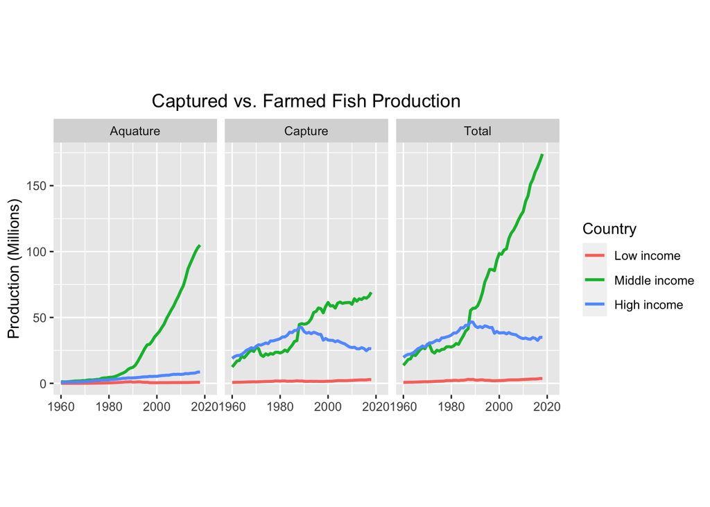

```r
captured_vs_farmed %>%
  filter(Entity %in% income_group) %>%
  rename("Aquature" = 4, "Capture" = 5) %>%
  mutate(Total = Aquature + Capture) %>%
  mutate(Entity = factor(Entity, levels = income_group)) %>%
  pivot_longer(cols = (4:6), names_to = 'Type', values_to = "Production") %>%
  ggplot(aes(x = Year, y = Production/1000000, color = Entity)) +
  geom_line(lwd = 1) +
  facet_wrap(~ Type) +
  labs(color = "Country",
       title = "Captured vs. Farmed Fish Production",
       y = "Production (Millions)") +
  scale_x_continuous(limits = c(1960, 2022)) +
  theme(legend.position = "right", plot.title = element_text(hjust = 0.5), axis.title.x = element_blank()) +
  coord_fixed(ratio = 0.55)
```

Visualisation 1 indicates that for low-income countries, there is no significant change in production for both aquaculture and capture fisheries over the years. For middle-income countries, the proportion of aquaculture production experiences a notable increase, while the proportion of capture fisheries decreases. Aquaculture exhibits faster growth compared to capture fisheries. For high-income countries, production consists of mostly capture fisheries, with aquaculture contributing a smaller proportion. Capture fisheries exhibit a slight increase followed by a decrease, with the 2020 production level comparable to the 1970s. Aquaculture production increases slightly, but the proportion remains small.

## 2.2 Dataset Preparation for Visualisations 2 and 3

We defined income groups based on the classification from the World Bank (2023). We assigned each country in the datasets `consumption` and `production` to an income group (low-income, middle-income or high-income) using the provided lists of countries.

```r
# Get the classification from World Bank

low_income <- c("Afghanistan", "North Korea", "Burkina Faso", "Liberia", "Sudan", "Burundi", "Madagascar", "Syrian Arab Republic", "Central African Republic", "Malawi", "Togo", "Chad", "Mali", "Uganda", "Mozambique", "Yemen", "Eritrea", "Niger", "Ethiopia", "Rwanda", "Gambia", "Sierra Leone", "Guinea-Bissau","Somalia")

lower_middle_income <- c("Angola", "Jordan", "Philippines", "Algeria", "India", "Samoa", "Bangladesh", "Iran", "Sao Tome and Principe", "Benin", "Kenya", "Senegal", "Solomon Islands", "Bolivia", "Kyrgyzstan", "Sri Lanka", "Cape Verde", "Laos",  "Tanzania", "Cambodia", "Lebanon", "Tajikistan", "Cameroon", "Lesotho", "Timor",  "Comoros", "Mauritania", "Tunisia", "Congo", "Ukraine", "Cote d'Ivoire", "Mongolia", "Uzbekistan", "Djibouti", "Morocco", "Vanuatu", "Egypt", "Myanmar", "Vietnam", "Eswatini", "Nepal", "Zambia", "Ghana", "Nicaragua", "Zimbabwe", "Guinea", "Nigeria", "Haiti", "Pakistan", "Honduras", "Papua New Guinea", "Kiribati")

upper_middle_income <- c("Albania", "Fiji", "North Macedonia", "Argentina", "Gabon", "Palau", "Armenia", "Georgia", "Paraguay", "Azerbaijan", "Grenada", "Peru", "Belarus","Guatemala", "Russia","USSR", "Belize", "Indonesia", "Serbia", "Bosnia and Herzegovina", "Iraq", "South Africa", "Botswana", "Jamaica", "Saint Lucia", "Brazil", "Kazakhstan", "Saint Vincent and the Grenadines", "Bulgaria", "Kosovo", "Suriname", "China", "Libya", "Thailand", "Colombia", "Malaysia", "Tonga", "Costa Rica", "Maldives", "Türkiye", "Cuba", "Turkmenistan", "Dominica", "Mauritius", "Tuvalu", "Dominican Republic", "Mexico", "El Salvador", "Moldova", "Equatorial Guinea", "Montenegro", "Ecuador", "Namibia", "Serbia and Montenegro", "Yugoslavia", "Turkey","Venezuela")

high_income <- c("Samoa", "Germany", "Oman", "Andorra", "Gibraltar", "Panama", "Antigua and Barbuda", "Greece", "Poland", "Aruba", "Greenland", "Portugal", "Australia", "Guam", "Puerto Rico", "Austria", "Hong Kong", "Qatar", "Bahamas", "Hungary", "Romania", "Bahrain", "Iceland",  "San Marino", "Barbados", "Ireland", "Saudi Arabia", "Belgium", "Isle of Man", "Seychelles",  "Israel", "Singapore", "British Virgin Islands", "Italy", "Sint Maarten (Dutch part)", "Brunei", "Japan", "Slovakia", "Canada", "South Korea", "Slovenia", "Cayman Islands", "Kuwait", "Spain", "Channel Islands", "Latvia", "Saint Kitts and Nevis", "Chile","Liechtenstein", "St. Martin", "Croatia", "Lithuania", "Sweden", "Curaçao", "Luxembourg", "Switzerland", "Cyprus", "Macao", "Taiwan", "Czechia", "Malta", "Trinidad and Tobago", "Denmark", "Monaco", "Turks and Caicos Islands", "Estonia", "Nauru", "United Arab Emirates", "Faroe Islands", "Netherlands", "United Kingdom", "Finland", "New Caledonia", "United States", "France", "New Zealand", "Uruguay", "French Polynesia", "Northern Mariana Islands", "Virgin Islands (U.S.)", "Guyana", "Norway", "Bermuda", "Polynesia")


classify_income_group <- function(entity) {
    if (entity %in% low_income) {
        return("Low income")
    } else if (entity %in% lower_middle_income) {
        return("Middle income")
    } else if (entity %in% upper_middle_income) {
        return("Middle income")
    } else if (entity %in% high_income) {
        return("High income")
    } else {
        return(NA)
    }
}


# Apply the classification to the dataset
consumption$Income_Group <- sapply(consumption$Entity, classify_income_group)
production$Income_Group <- sapply(production$Entity, classify_income_group)

production %>% mutate(Income_Group = factor(Income_Group, levels = income_group)) -> production
consumption %>% mutate(Income_Group = factor(Income_Group, levels = income_group)) -> consumption
```

## 2.3 Visualisation 2

### Relative Changes in the Proportion of Fish Species across Income Groups over Time

To clean the dataset, we filtered out rows where the `Income_Group` column is not null. We then calculated the sum of production quantities for each species category (Pelagic Fish, Crustaceans, etc.) within each income group and year. Finally we converted the `Income_Group` column to a factor with ordered levels defined by the `income_group` variable. The relative proportions of the 7 species of fish are shown on the graph plotted. The main purpose is to visualise the dominant species produced across the three income groups and determine their relative changes over time.

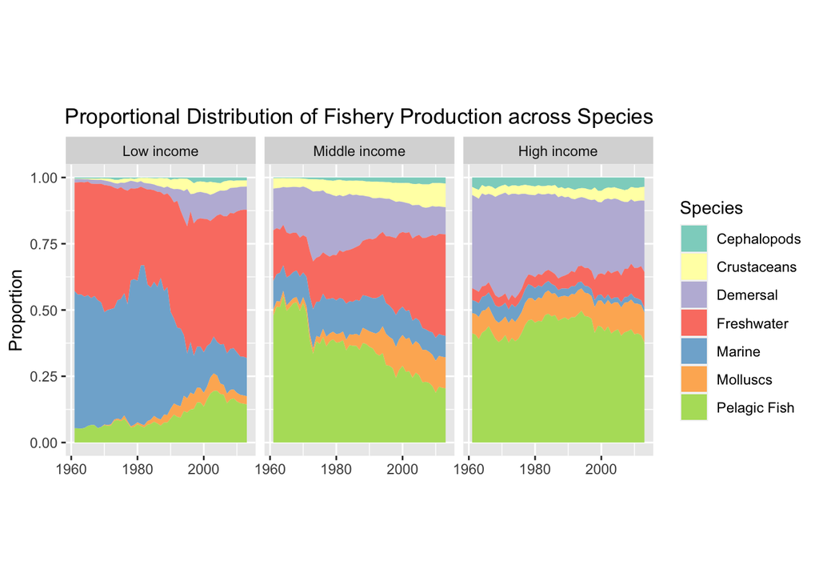

```r
production %>%
  filter(!is.na(Income_Group)) %>%
  rename("Pelagic_Fish" = 4, "Crustaceans" = 5, "Cephalopods" = 6, "Demersal" = 7,
         "Freshwater" = 8, "Molluscs" = 9, "Marine" = 10) %>%
  group_by(Income_Group, Year) %>%
  summarise(.groups = "keep", `Pelagic Fish` = sum(Pelagic_Fish, na.rm = T),
            Crustaceans = sum(Crustaceans, na.rm = T), Cephalopods = sum(Cephalopods, na.rm = T),
            Demersal = sum(Demersal, na.rm = T), Freshwater = sum(Freshwater, na.rm = T),
            Molluscs = sum(Molluscs, na.rm = T), Marine = sum(Marine, na.rm = T)) %>%
  ungroup() %>%
  pivot_longer(c(3:9), names_to = "Species", values_to = "Quantity") %>%
  mutate(Income_Group = factor(Income_Group, levels = income_group)) %>%
  ggplot(aes(x = Year, y = Quantity, fill = Species)) +
  geom_area(position = "fill") +
  facet_wrap(~ Income_Group) +
  scale_fill_brewer(palette = "Set3") +
  labs(title = "Proportional Distribution of Fishery Production across Species",
       y = "Proportion") +
  theme(legend.position = "right", plot.title = element_text(hjust = 0.5), axis.title.x = element_blank()) +
  coord_fixed(ratio = 80)
```

For low-income countries, the proportion of Marine Fish decreases significantly. Overall, there is a slight increase in the proportion of Freshwater Fish, Demersal and Pelagic Fish. The contribution of the remaining three species (Crustaceans, Cephalopods, and Molluscs) to fish production remains relatively insignificant. For middle-income countries, there’s a notable increase in Freshwater Fish Quantity, accompanied by slight increases in Molluscs, Crustaceans and Cephalopods. Pelagic Fish production sees a significant decrease in quantity, while Demersal production shows little to no change. In high-income countries, the majority of fish production comes from Demersal and Pelagic fish, with Pelagic fish levels remaining relatively constant and Demersal fish decreasing over time. There are slight increases observed in Freshwater and Molluscs production, while Marine, Crustaceans and Cephalopods show minimal change and remain relatively insignificant contributors to overall fish production.

This could be attributed to several underlying factors: Technological advancements in middle and high-income countries could enhance freshwater resource exploitation and targeted harvesting of other species over time, while low-income countries are unable to harvest fish from the deep sea, such as Demersal, due to a lack of advanced technologies (Cooke et al., 2023). Environmental degradation might contribute to declines in marine fish production in low-income countries, whereas stricter regulations in wealthier nations promote sustainable marine resource management. Moreover, as wealth increases, dietary preferences shift towards diverse protein sources, fostering increased production of freshwater fish and shellfish in middle and high-income countries (Gerbens-Leenes et al., 2010).

## 2.4 Visualisation 3

### Fish Consumption Level of Each Country in 2017

For Visualisation 3, we utilise the `consumption` dataset to generate a bivariate choropleth map representing the 2017 level of fishery consumption across countries categorized by income groups worldwide. The aim is to investigate the potential relationship between fishery consumption and income groups.

To clean the dataset, we filtered out rows with missing country codes and restricted the data to the year 2017. We then computed quantile values for consumption per capita and assigned quantile labels to each observation. Finally, we joined the processed dataset with world map data to enable geographic visualisation. Moreover, we employed a customised colour palette which fulfils two criteria: it provides a distinct hue for each income group and varies the brightness for each consumption level quantile. The colour of each country on the map represents both its income group and consumption quantile, providing a visual representation of how these variables intersect across different regions of the world.

```r
df <- consumption %>%
  filter(!is.na(Code), Year == 2017) %>%
  rename("consumption_capita" = 4) %>%
  select(-Code, -Year) %>%
  mutate(Entity = case_when(Entity == 'United States'~'USA',
                            Entity == 'United Kingdom'~'UK',
                            Entity == 'Congo'~'Democratic Republic of the Congo',
                            Entity == 'Czechia'~'Czech Republic',
                            .default = Entity))

# Get the quantile values for consumption per capita
quantiles <- df %>%
  reframe(quantiles = quantile(consumption_capita, probs = seq(0.25,1,0.25))) %>%
  pull(quantiles)

df <- df %>% mutate(quartile = case_when(consumption_capita < quantiles[1] ~ 'Q1',
                                         consumption_capita < quantiles[2] ~ 'Q2',
                                         consumption_capita < quantiles[3] ~ 'Q3',
                                         consumption_capita <= quantiles[4] ~ 'Q4'))

# Create an ordered factor for the combined variable
df %>% mutate(combined = interaction(Income_Group, quartile, sep=', ')) -> df

combined_levels = c()
for (level in paste(c('Low','Middle','High'),'income')) {
  for (i in 1:4) {q = paste(level, paste('Q', i, sep = ''), sep=', ')
    combined_levels = append(combined_levels, q)}
}
df %>% mutate(combined = factor(combined, levels = combined_levels)) -> df


# Join datasets
world <- map_data('world')
df <- df %>% left_join(world, by = c("Entity" = "region"))
```

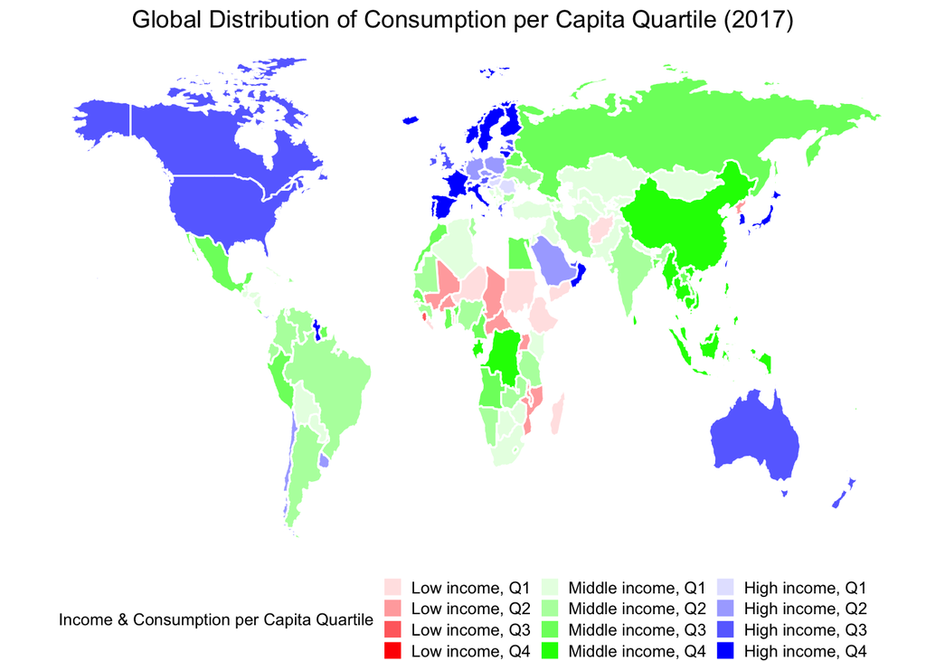

```r
# Create a customized color palette fulfilling the two requirements:
#   (1) distinct hue for each income group
#   (2) different brightness for each consumption level
palette_colors <- c("#FF000022","#FF000066", "#FF0000AA", "#FF0000FF",
                    "#00FF0022", "#00FF0066", "#00FF00AA","#00FF00FF",
                    "#0000FF22", "#0000FF66", "#0000FFAA", "#0000FFFF")


ggplot(data = df) +
  geom_polygon(data = df, aes(x = long, y = lat, group = group, fill = combined), color = "white") +
  scale_fill_manual(values = palette_colors) +
  labs(title = "Global Distribution of Consumption per Capita Quartile (2017)",
       fill = "Income & Consumption per Capita Quartile") +
  theme_void() +
  theme(plot.title = element_text(hjust = 0.5), legend.position = "bottom", legend.key.size = unit(0.8, "lines"),
        legend.text = element_text(size = 9), legend.title = element_text(size = 9)) +
  guides(fill = guide_legend(ncol = 3))
```

From Visualisation 3, low-income countries tend to exhibit lighter colours, indicating lower consumption levels, while high-income countries tend to have darker colours, indicating higher consumption levels. Middle-income countries display a mix of light and dark colours, reflecting varying levels of consumption.

The disparities in fishery consumption observed across income groups in Visualisation 3 can be attributed to a combination of factors. High-income countries demonstrate higher consumption levels possibly due to their greater financial resources and well-developed infrastructure facilitating accessibility (Supartini et al., 2018). Government subsidies and supportive policies further contribute to affordability in these regions. In contrast, low-income countries face economic constraints and distribution challenges, leading to lower consumption levels. Environmental factors such as access to marine resources also play a role, with high-income countries benefiting from proximity to fishing grounds (Zhang and Chen, 2022). Varied levels of consumption among middle-income countries could be due to the diverse geographical conditions and cultural preferences that influence fishery consumption (Ibrahim et al., 2022).

# 3. Discussion

The 3 visualisations illustrate the complex relationship between a country’s fishing industry and its income level. Low-income countries grappling with economic and developmental constraints are characterised by consistently low fishery production (Visualisation 1). This limited development is further exacerbated by a lack of advanced technology and restricted access to deep-sea resources resulting in limited access to various species (Visualisation 2), constraining their capacity to engage in extensive fishing activities and results in low consumption (Visualisation 3).

In contrast, middle-income countries have undergone shifts in their fisheries production patterns, marked by a noticeable surge in aquaculture activities (Visualisation 1) and targeted harvesting of Freshwater fish (Visualisation 2). This transition can be attributed to factors including technological advancements that facilitate efficient exploitation of freshwater resources and the implementation of stringent environmental regulations that promote sustainable marine resource management practices. There isn’t a consistent trend for consumption across the countries (Visualisation 3), possibly due to the countries’ diverse conditions.

The trend in the fishery industry across high-income countries remains relatively stable over the years. The decrease in capture fisheries observed in the 1990s (Visualisation 1) can be attributed to the implementation of regulatory measures. Despite this decline, the proportional composition of fish species produced remains relatively constant (Visualisation 2), suggesting a well-established and resilient fishery industry. The higher levels of fishery consumption compared to their counterparts (Visualisation 3) can be explained by advanced financial resources and infrastructure.

In conclusion, the intricate relationship between income levels and fishery industries on the global scale is shaped by a multitude of factors, including economic capacity, infrastructure, environmental conditions and policy regulations. Understanding and navigating these complexities is crucial for achieving sustainable and equitable development in the fisheries sector.

# 4. References

Cooke, Steven J, et al. “Managing Exploitation of Freshwater Species and Aggregates to Protect and Restore Freshwater Biodiversity.” Environmental Reviews, 2 Aug. 2023, https://doi.org/10.1139/er-2022-0118.

Gerbens-Leenes, P.W., et al. “Food Consumption Patterns and Economic Growth. Increasing Affluence and the Use of Natural Resources.” Appetite, vol. 55, no. 3, Dec. 2010, pp. 597–608, www.sciencedirect.com/science/article/pii/S0195666310005118, https://doi.org/10.1016/j.appet.2010.09.013.

Issifu, Ibrahim, et al. “Drivers of Seafood Consumption at Different Geographical Scales.” Journal of Sustainability Research, 2022, https://doi.org/10.20900/jsr20220012.

Richards, Andrew H. “Problems of Drift-Net Fisheries in the South Pacific.” Marine Pollution Bulletin, vol. 29, no. 1, 1 Jan. 1994, pp. 106–111, www.sciencedirect.com/science/article/abs/pii/0025326X94904332, https://doi.org/10.1016/0025-326X(94)90433-2.

Supartini, Atin, et al. “Changes in Fish Consumption Desire and Its Factors: A Comparison between the United Kingdom and Singapore.” Foods, vol. 7, no. 7, 26 June 2018, p. 97, https://doi.org/10.3390/foods7070097.

The Food and Agriculture Organization of the United Nations. “World Agriculture: Towards 2015/2030 - an FAO Perspective.” Www.fao.org, www.fao.org/3/Y4252E/y4252e09.htm#:~:text=During%20the%201990s%2C%20the%20production. Accessed 18 Apr. 2024.

Virdin, John, et al. “Fishing for Subsistence Constitutes a Livelihood Safety Net for Populations Dependent on Aquatic Foods around the World.” Nature Food, 25 Sept. 2023, pp. 1–12, www.nature.com/articles/s43016-023-00844-4#:~:text=Total%20number%20of%20people%20engaged%20in%20subsistence%20fishing&text=The%2052.8%20million%20people%20estimated, https://doi.org/10.1038/s43016-023-00844-4.

World Bank. “World Bank Country and Lending Groups.” The World Bank, 2023, datahelpdesk.worldbank.org/knowledgebase/articles/906519-world-bank-country-and-lending-groups.

Zhang, Hongyan, and Suisui Chen. “Overview of Research on Marine Resources and Economic Development.” Marine Economics and Management, vol. 5, no. 1, 4 May 2022, pp. 69–83, https://doi.org/10.1108/maem-11-2021-0012.

# 5. About

This project was developed for DSA2101 Essential Data Analytics Tools: Data Visualization at the National University of Singapore (NUS). The team is comprised of the following members:

| Name | Year | Major | Responsibilities |
| --- | --- | --- | --- |
| Xu Yifei | 2 | Data Science & Analytics | Dataset preparation & cleaning |
| Hu Can | 2 | Data Science & Analytics | Visualisations 1 & 2 |
| Lew Choon Hean | 2 | Data Science & Analytics | Visualisation 3 |
| Ma Xianzhou | 2 | Data Science & Economics | Report |